# Bike sharing dataset

Maryam Ghalambor

2022-12-03

## Introduction:

A junior data analyst works in the marketing analyst team at Cyclistic, a bike-share company in Chicago. The director of marketing believes the company’s future success depends on maximizing the number of annual memberships. Therefore, the team wants to understand how casual riders and annual members use Cyclistic bikes differently. This case study is part of the Google Data Analytics Professional Certificate. To finalize this case study, six different phases should be completed including: Ask, Prepare, Process, Analyze, Share and Act.

1. Ask phase: In this case study the main question is how casual riders and annual members use Cyclistic bikes differently in order to determine the best marketing strategy to convert casual members to anual riders.
2. Prepare phase: The Cyclistic’s historical trip data (the previous 12 months as dataset is organized by mouth) is downloaded from https://divvy-tripdata.s3.amazonaws.com/index.html. For the purposes of this case study, the datasets are appropriate and will enable you to answer the business questions. The data has been made available by Motivate International Inc. under this license (https://ride.divvybikes.com/data-license-agreement). This is public data that you can use to explore how different customer types are using Cyclistic bikes.
3. Process phase: Importing data to RStudio and checking the data for some errors, transforming and cleaning the data to be able to work with more efficiently.
- The summary of final dataset after cleaning process:

```r
nrow(all_trips)
```

```
## [1] 5828235
```

```r
dim(all_trips)
```

```
## [1] 5828235      14
```

```r
colnames(all_trips)
```

```
##  [1] "ride_id"            "rideable_type"      "started_at"
##  [4] "ended_at"           "start_station_name" "start_station_id"
##  [7] "end_station_name"   "end_station_id"     "member_casual"
## [10] "date"               "month"              "day"
## [13] "year"               "day_of_week"
```

```r
str(all_trips)
```

```
## 'data.frame':    5828235 obs. of  14 variables:
##  $ ride_id           : chr  "620BC6107255BF4C" "4471C70731AB2E45" "26CA69D43D15EE14" "362947F0437E1514" ...
##  $ rideable_type     : chr  "electric_bike" "electric_bike" "electric_bike" "electric_bike" ...
##  $ started_at        : chr  "2021-10-22 12:46:42" "2021-10-21 09:12:37" "2021-10-16 16:28:39" "2021-10-16 16:17:48" ...
##  $ ended_at          : chr  "2021-10-22 12:49:50" "2021-10-21 09:14:14" "2021-10-16 16:36:26" "2021-10-16 16:19:03" ...
##  $ start_station_name: chr  "Kingsbury St & Kinzie St" "" "" "" ...
##  $ start_station_id  : chr  "KA1503000043" "" "" "" ...
##  $ end_station_name  : chr  "" "" "" "" ...
##  $ end_station_id    : chr  "" "" "" "" ...
##  $ member_casual     : chr  "member" "member" "member" "member" ...
##  $ date              : Date, format: "2021-10-22" "2021-10-21" ...
##  $ month             : chr  "10" "10" "10" "10" ...
##  $ day               : chr  "22" "21" "16" "16" ...
##  $ year              : chr  "2021" "2021" "2021" "2021" ...
##  $ day_of_week       : chr  "Friday" "Thursday" "Saturday" "Saturday" ...
```

```r
head(all_trips)
```

```
##            ride_id rideable_type          started_at            ended_at
## 1 620BC6107255BF4C electric_bike 2021-10-22 12:46:42 2021-10-22 12:49:50
## 2 4471C70731AB2E45 electric_bike 2021-10-21 09:12:37 2021-10-21 09:14:14
## 3 26CA69D43D15EE14 electric_bike 2021-10-16 16:28:39 2021-10-16 16:36:26
## 4 362947F0437E1514 electric_bike 2021-10-16 16:17:48 2021-10-16 16:19:03
## 5 BB731DE2F2EC51C5 electric_bike 2021-10-20 23:17:54 2021-10-20 23:26:10
## 6 7176307BBC097313 electric_bike 2021-10-21 16:57:37 2021-10-21 17:11:58
##         start_station_name start_station_id end_station_name end_station_id
## 1 Kingsbury St & Kinzie St     KA1503000043
## 2
## 3
## 4
## 5
## 6
##   member_casual       date month day year day_of_week
## 1        member 2021-10-22    10  22 2021      Friday
## 2        member 2021-10-21    10  21 2021    Thursday
## 3        member 2021-10-16    10  16 2021    Saturday
## 4        member 2021-10-16    10  16 2021    Saturday
## 5        member 2021-10-20    10  20 2021   Wednesday
## 6        member 2021-10-21    10  21 2021    Thursday
```

4. Analyze phase: In this step, by using R codes, targeted trends were drawn out for visualization purposes.
- Descriptive analysis:
1. straight average in second (total ride length / rides):

```r
mean(final_trips$ride_length)
```

```
## [1] 1176.281
```

2. midpoint number in the ascending array of ride lengths in second:

```r
median(final_trips$ride_length)
```

```
## [1] 629
```

3. longest ride in second:

```r
max(final_trips$ride_length)
```

```
## [1] 2442301
```

4. shortest ride in second:

```r
min(final_trips$ride_length)
```

```
## [1] 0
```

5. summary of important details:

```r
summary(final_trips$ride_length)
```

```
##    Min. 1st Qu.  Median    Mean 3rd Qu.    Max.
##       0     356     629    1176    1131 2442301
```

- some important comparisons: ** Member vs. Casual**

```r
aggregate(final_trips$ride_length ~ final_trips$usertype, FUN = mean)
```

```
##   final_trips$usertype final_trips$ride_length
## 1               casual               1761.6450
## 2               member                766.1175
```

```r
aggregate(final_trips$ride_length ~ final_trips$usertype, FUN = max)
```

```
##   final_trips$usertype final_trips$ride_length
## 1               casual                 2442301
## 2               member                   93594
```

```r
aggregate(final_trips$ride_length ~ final_trips$usertype, FUN = min)
```

```
##   final_trips$usertype final_trips$ride_length
## 1               casual                       0
## 2               member                       0
```

5. Share phase: creating some visualizations in order to show different trends for different users.
- visualize the number of various users:

[figure not shown]

- visualize the percentage of different users:

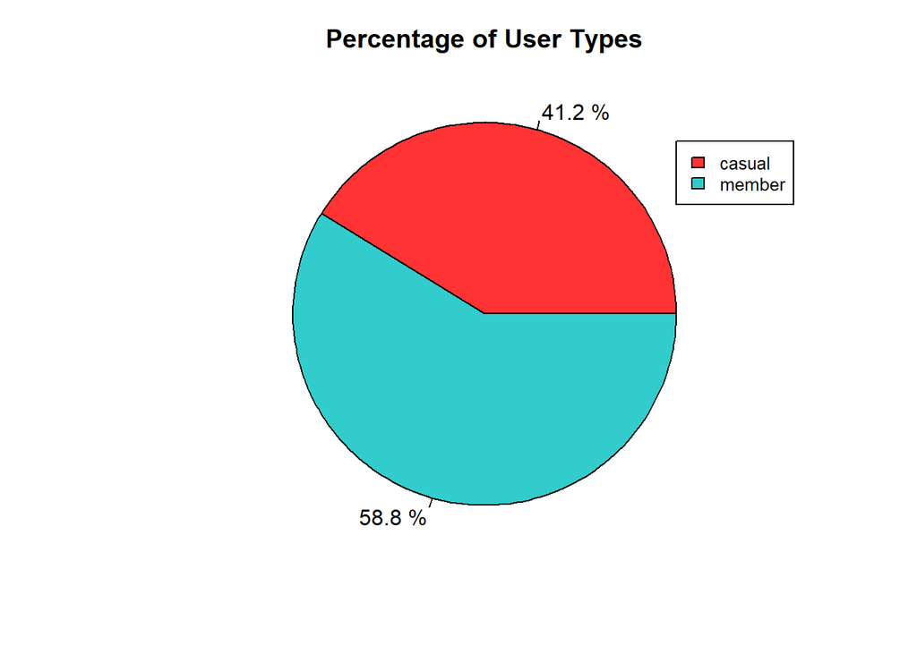

- visualize the number of rides by usertype:

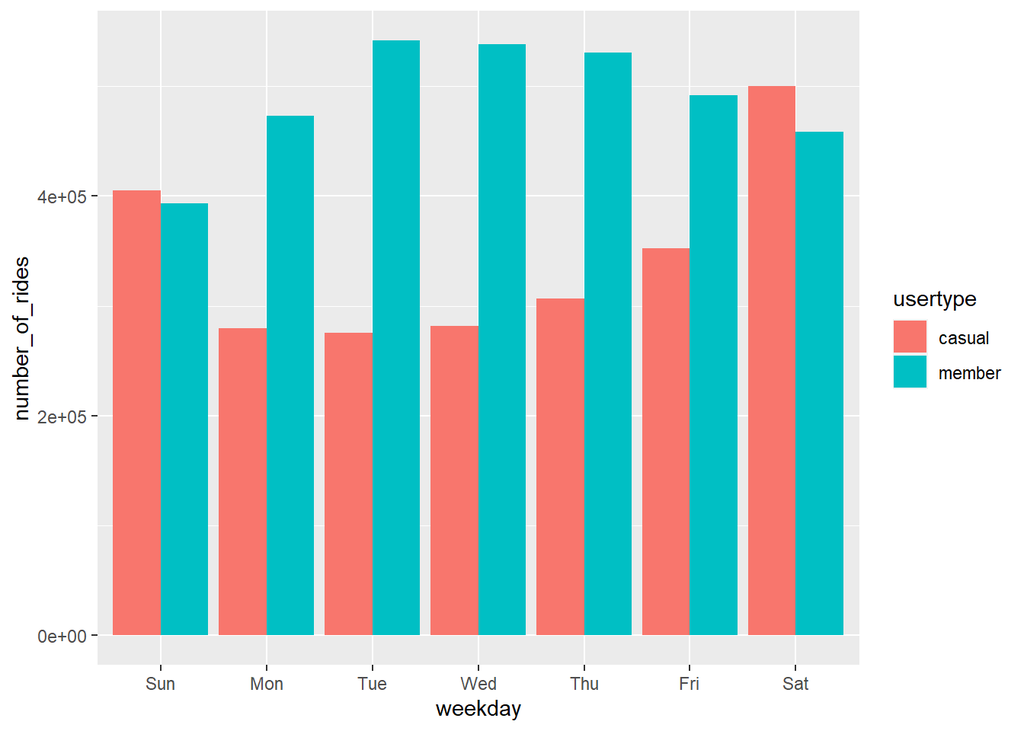

- visualization of average duration for different user types:

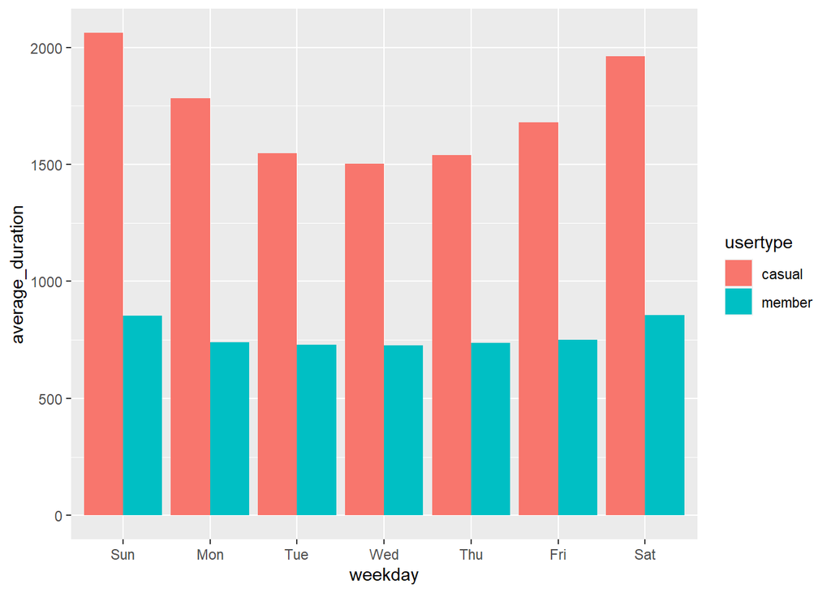

6. Act phase:

- RECOMMENDATION: To convert casual riders to members, offering special prices for renting bikes for more number of hours or days, on weekends and on the busiest days might be helpful.